# EDA on Haberman

```python
import pandas as pd
import numpy as np
import seaborn as sns
import matplotlib.pyplot as plt
```

```python
df=pd.read_csv("haberman.csv")
```

```python
df
```

|  | 30 | 64 | 1 | 1.1 |
| --- | --- | --- | --- | --- |
| 0 | 30 | 62 | 3 | 1 |
| 1 | 30 | 65 | 0 | 1 |
| 2 | 31 | 59 | 2 | 1 |
| 3 | 31 | 65 | 4 | 1 |
| 4 | 33 | 58 | 10 | 1 |
| ... | ... | ... | ... | ... |
| 300 | 75 | 62 | 1 | 1 |
| 301 | 76 | 67 | 0 | 1 |
| 302 | 77 | 65 | 3 | 1 |
| 303 | 78 | 65 | 1 | 2 |
| 304 | 83 | 58 | 2 | 2 |

305 rows × 4 columns

```python
df.shape
```

```
(305, 4)
```

```python
df.isnull().sum()
```

```
30     0
64     0
1      0
1.1    0
dtype: int64
```

```python
df["1.1"].value_counts()
```

[output not shown]

Observation:

1. There are 305 rows and 4 columns including class column.
2. There are no missing value.
3. This data set is unbalanced as it has 224 patient of one category and 81 patient of other category.

```python
df["1.1"]=df["1.1"].map({1:"Yes",2:"No"})
```

```python
df.head()
```

|  | 30 | 64 | 1 | 1.1 |
| --- | --- | --- | --- | --- |
| 0 | 30 | 62 | 3 | Yes |
| 1 | 30 | 65 | 0 | Yes |
| 2 | 31 | 59 | 2 | Yes |
| 3 | 31 | 65 | 4 | Yes |
| 4 | 33 | 58 | 10 | Yes |

```python
df.describe()
```

|  | 30 | 64 | 1 |
| --- | --- | --- | --- |
| count | 305.000000 | 305.000000 | 305.000000 |
| mean | 52.531148 | 62.849180 | 4.036066 |
| std | 10.744024 | 3.254078 | 7.199370 |
| min | 30.000000 | 58.000000 | 0.000000 |
| 25% | 44.000000 | 60.000000 | 0.000000 |
| 50% | 52.000000 | 63.000000 | 1.000000 |
| 75% | 61.000000 | 66.000000 | 4.000000 |
| max | 83.000000 | 69.000000 | 52.000000 |

```python
survive_yes=df[df["1.1"]=="Yes"]
survive_no=df[df["1.1"]=="No"]
```

```python
survive_yes.describe()
```

|  | 30 | 64 | 1 |
| --- | --- | --- | --- |
| count | 224.000000 | 224.000000 | 224.000000 |
| mean | 52.116071 | 62.857143 | 2.799107 |
| std | 10.937446 | 3.229231 | 5.882237 |
| min | 30.000000 | 58.000000 | 0.000000 |
| 25% | 43.000000 | 60.000000 | 0.000000 |
| 50% | 52.000000 | 63.000000 | 0.000000 |
| 75% | 60.000000 | 66.000000 | 3.000000 |
| max | 77.000000 | 69.000000 | 46.000000 |

```python
survive_no.describe()
```

|  | 30 | 64 | 1 |
| --- | --- | --- | --- |
| count | 81.000000 | 81.000000 | 81.000000 |
| mean | 53.679012 | 62.827160 | 7.456790 |
| std | 10.167137 | 3.342118 | 9.185654 |
| min | 34.000000 | 58.000000 | 0.000000 |
| 25% | 46.000000 | 59.000000 | 1.000000 |
| 50% | 53.000000 | 63.000000 | 4.000000 |
| 75% | 61.000000 | 65.000000 | 11.000000 |
| max | 83.000000 | 69.000000 | 52.000000 |

Observation:

1. The avarage age and year of operation of person in both the classes are approx same.
2. But the # of positive auxilary node is differ by approx 5. The survive class has less number of positive auxilary nodes compare to non-survive class.

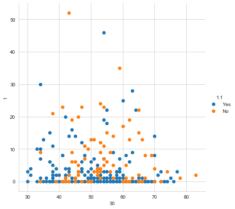

```python
sns.set_style("whitegrid")
sns.FacetGrid(df,hue="1.1",height=6) \
   .map(plt.scatter,"30","1") \
   .add_legend()
plt.show()
```

Obsevation:

1. From above 2D scatter plot we see that we cannot easily distinguish the two categories using the attribute "Age"(30) and "Number of positive auxilary nodes detected"(1).
2. The person whose # positive auxilary node is 0 or 1 are more likely to survive irrespective of their ages.
3. The person whose # positive auxilary node is 10 or more and age >=50 are less chances of survive.
4. There are very few people whose # positive auxilary node>=40,seems like they are outlier.

```python
import plotly.express as px
fig=px.scatter_3d(df,x="30",y="1",z="64",color="1.1")
fig.show()
```

[interactive chart not shown]

Observation: This 3D scatter plot is also not help us as we still cannot distinguish between two categoris. So let's try pair plot to see any combination will help us or not!!!!!

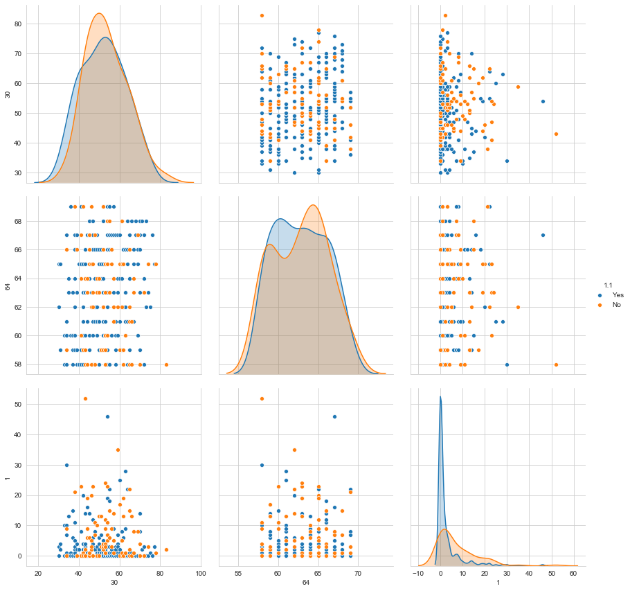

```python
sns.set_style("whitegrid")
sns.pairplot(df,hue="1.1",height=4)
```

Observation:

1. From the above 3c2=3 plot we clearly see that two attribute/feature together cannot helpfull to achieve our goal.Although people having age<=40 are more likely to survived irrespective of year of operation.

```python
df_survive_more=df[df["1.1"]=="Yes"]
df_survive_less=df[df["1.1"]=="No"]
```

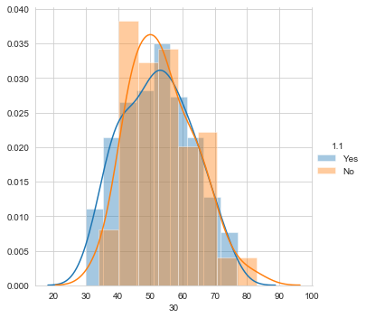

```python
sns.set_style("whitegrid")
sns.FacetGrid(df,hue="1.1",height=5) \
   .map(sns.distplot,"30") \
   .add_legend()
plt.show()
```

Observation:

1. Two density plot are almost overlap,this is not good for our objective.
2. People whose age are in between 40-60 are less chances to survive and 60-76 the chances are equally likely.
3. People whose age are in between 20-40 are more chances to survive.

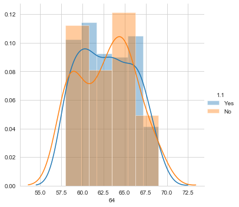

```python
sns.set_style("whitegrid")
sns.FacetGrid(df,hue="1.1",height=5) \
   .map(sns.distplot,"64") \
   .add_legend()
plt.show()
```

Observation:

1. In the year 1965 , more unsuccessful opeartion happened and in the year 1961,more successful operation was happened.

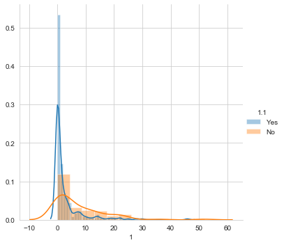

```python
sns.set_style("whitegrid")
sns.FacetGrid(df,hue="1.1",height=5) \
   .map(sns.distplot,"1") \
   .add_legend()
plt.show()
```

Observation:

```
[0.83482143 0.08035714 0.02232143 0.02678571 0.01785714 0.00446429
 0.00892857 0.         0.         0.00446429]
[ 0.   4.6  9.2 13.8 18.4 23.  27.6 32.2 36.8 41.4 46. ]
[0.56790123 0.14814815 0.13580247 0.04938272 0.07407407 0.
 0.01234568 0.         0.         0.01234568]
[ 0.   5.2 10.4 15.6 20.8 26.  31.2 36.4 41.6 46.8 52. ]
```

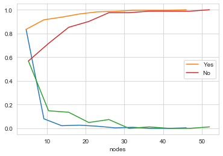

```python
counts,bin_edges=np.histogram(survive_yes["1"],bins=10,density=True)
pdf=counts/(sum(counts))
print(pdf)
print(bin_edges)
cdf=np.cumsum(pdf)
plt.plot(bin_edges[1:],pdf)
plt.plot(bin_edges[1:],cdf,label="Yes")
plt.xlabel("nodes")

counts,bin_edges=np.histogram(survive_no["1"],bins=10,density=True)
pdf=counts/(sum(counts))
print(pdf)
print(bin_edges)
cdf=np.cumsum(pdf)
plt.plot(bin_edges[1:],pdf)
plt.plot(bin_edges[1:],cdf,label="No")
plt.legend()


plt.show()
```

Observation:

1. 83% people who survived having # of positive auxilary node <=4.
2. on the other hand there are people having 0 or 1 positive auxilary node but not survived.So,on the basis of this feature we cannot classify.

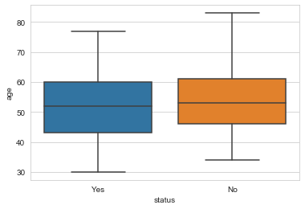

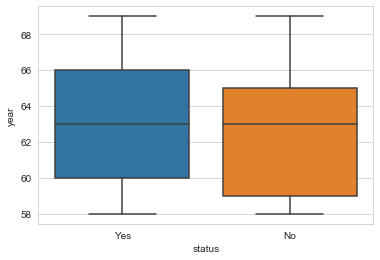

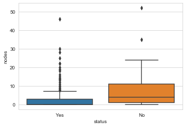

```python
sns.boxplot(x="1.1",y="30",data=df)
plt.xlabel("status")
plt.ylabel("age")
plt.show()
sns.boxplot(x="1.1",y="64",data=df)
plt.xlabel("status")
plt.ylabel("year")
plt.show()
sns.boxplot(x="1.1",y="1",data=df)
plt.xlabel("status")
plt.ylabel("nodes")
plt.show()
```

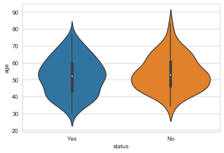

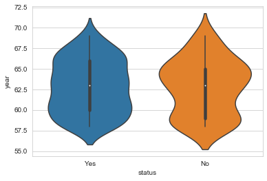

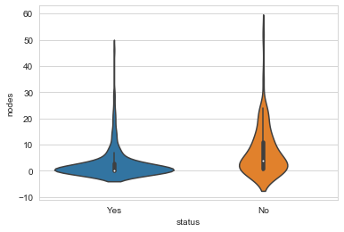

```python
sns.violinplot(x="1.1",y="30",data=df)
plt.xlabel("status")
plt.ylabel("age")
plt.show()

sns.violinplot(x="1.1",y="64",data=df)
plt.xlabel("status")
plt.ylabel("year")
plt.show()

sns.violinplot(x="1.1",y="1",data=df)
plt.xlabel("status")
plt.ylabel("nodes")
plt.show()
```

Observation:

1. From the first two box plot we see that there are almost overlap between two class.
2. Box plot corresponding to node is much less overlap compare to other. People having nodes between 0-2 are survived and having nodes between 1-11 are not survived.
3. Same conclusion observed from violin plot.

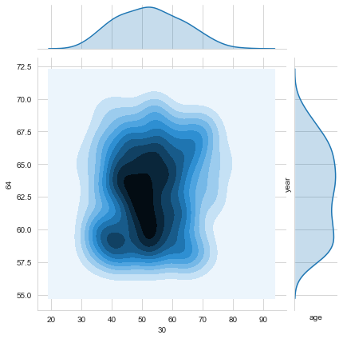

```python
sns.jointplot(x="30",y="64",data=df,kind="kde")
plt.xlabel("age")
plt.ylabel("year")
plt.show()
```

Observation:

1. Between 1958-1963,people having age 45-55 are operated much.

Conclusion:

1. Survival is inversely proportional to the number of positive auxilary nodes.But there are some people with exception.
2. The features are given in this dataset are not sufficient for classification.